# OmniSciKit 使用教程

Ablikim Ali

2026-04-29

## 概述

**OmniSciKit** 是一个全面的临床研究和生物统计R包，覆盖临床试验样本量计算、功效分析、统计分析、数据可视化、效应量计算、诊断试验评估和临床工具等核心功能。

### 安装

```r
if (!requireNamespace("pak", quietly = TRUE))
    install.packages("pak")
pak::pak("ablikimeli/OmniSciKit")
```

### 加载包与数据集

```r
library(OmniSciKit)
data(omni_glucose)
data(omni_cancer)
data(omni_diagnostic)
data(omni_cardio)
```

内置8个临床数据集：`omni_glucose`（血糖控制，500例）、`omni_cancer`（癌症生存，300例）、`omni_diagnostic`（诊断试验，450例）、`omni_cardio`（心血管风险，400例）等。

# 1. 样本量计算

样本量计算是临床试验设计的核心环节，直接决定研究的把握度和伦理合理性。

## 1.1 单样本t检验

**概念**：检验样本均数是否与已知总体均数存在差异，如比较新治疗组HbA1c是否与目标值100有差异。

```r
ss_ttest_one_sample(mu0 = 100, mu1 = 105, sd = 15, power = 0.8)
#
# === Sample Size Calculation ===
# Method: One-sample t-test
# Sample size: 71
# Power: 0.8
# Alpha: 0.05
#
# Formula: n = (Z_{α/2} + Z_β)² × σ² / δ²
# Reference: Chow et al. (2017) Sample Size Calculations in Clinical Research, 3rd ed.
```

## 1.2 配对t检验

**概念**：配对设计如同一患者治疗前后的比较。

```r
ss_ttest_paired(delta = 5, sd_diff = 10)
#
# === Sample Size Calculation ===
# Method: Paired t-test
# Sample size: 32
# Power: 0.8
# Alpha: 0.05
#
# Formula: n = (Z_{α/2} + Z_β)² × σ²_d / δ²
# Reference: Chow et al. (2017) Sample Size Calculations in Clinical Research, 3rd ed.
```

## 1.3 两样本t检验

```r
ss_ttest(delta = 0.5, sd = 1)
#
# === Sample Size Calculation ===
# Method: Two-sample t-test (equal variances)
# Sample size per group: 63
# Total sample size: 126
# Group 1: 63 Group 2: 63
# Total sample size: 126
# Power: 0.8
# Alpha: 0.05
#
# Formula: n₁ = (Z_{α/2} + Z_β)² × σ² × (1+1/ρ) / δ²
# Reference: Chow et al. (2017) Sample Size Calculations in Clinical Research, 3rd ed.
```

## 1.4 非劣效性试验（均数）

**概念**：验证新疗法不劣于标准疗法，允许一定的临床可接受差异。常用于非劣效 margin 设定。

```r
ss_noninferiority_mean(margin = 3, sd = 8)
#
# === Sample Size Calculation ===
# Method: Non-inferiority test (means)
# Total sample size: 176
# Group 1: 88 Group 2: 88
# Power: 0.8
# Alpha: 0.05
#
# Formula: n₁ = (Z_α + Z_β)² × σ² × (1+1/ρ) / (δ - |μ_diff|)²
# Reference: Chow et al. (2017) Ch.4: Non-inferiority Trials
```

## 1.5 非劣效性试验（率）

```r
ss_noninferiority_prop(p_control = 0.8, margin = 0.1)
#
# === Sample Size Calculation ===
# Method: Non-inferiority test (proportions)
# Total sample size: 396
# Group 1: 198 Group 2: 198
# Power: 0.8
# Alpha: 0.05
#
# Formula: n₁ = (Z_α√(p̄(1-p̄)(1+1/ρ)) + Z_β√(p_c(1-p_c)+p_t(1-p_t)/ρ))² / δ²_eff
# Reference: Farrington & Manning (1990) Statistics in Medicine, 9(12), 1447-1454
```

## 1.6 等效性试验（TOST）

**概念**：验证两种疗法等效，双向检验。生物等效性研究中常用。

```r
ss_equivalence_mean(delta = 5, sd = 10)
#
# === Sample Size Calculation ===
# Method: Equivalence test (means)
# Total sample size: 100
# Group 1: 50 Group 2: 50
# Power: 0.8
# Alpha: 0.05
#
# Formula: n₁ = (Z_α + Z_β)² × σ² × (1+1/ρ) / (δ - |μ_diff|)² (TOST)
# Reference: Chow et al. (2017) Ch.5: Equivalence Trials
```

## 1.7 生物等效性（均数比）

```r
ss_equivalence_ratio(theta = 0.95, cv = 0.2)
#
# === Sample Size Calculation ===
# Method: Equivalence test (ratio of means, 2x2 crossover)
# Total sample size: 18
# Power: 0.8
# Alpha: 0.05
#
# Formula: n_seq = (Z_α + Z_β)² × σ² / (δ - |log(θ)|)², σ² = log(1+CV²)
# Reference: Chow et al. (2017) Ch.8: Bioequivalence Studies
```

## 1.8 优效性试验

**概念**：验证新疗法优于标准疗法超过临床意义的阈值。

```r
ss_superiority_mean(delta = 5, sd = 10, true_diff = 8)
#
# === Sample Size Calculation ===
# Method: Superiority test (means)
# Total sample size: 350
# Group 1: 175 Group 2: 175
# Power: 0.8
# Alpha: 0.05
#
# Formula: n₁ = (Z_{α/2} + Z_β)² × σ² × (1+1/ρ) / (μ_diff - δ)²
# Reference: Chow et al. (2017) Ch.3: Superiority Trials
```

## 1.9 生存分析样本量（Log-rank）

**概念**：基于事件驱动设计，需要预估事件数和随访时间。常用于肿瘤临床试验。

```r
ss_survival_logrank(hr = 0.7, median_control = 12, accrual = 12, follow_up = 18)
#
# === Sample Size Calculation ===
# Method: Log-rank test (survival)
# Total sample size: 189
# Events needed: 247
# Power: 0.8
# Alpha: 0.05
#
# Formula: d = (Z_{α/2} + Z_β)² / (π(1-π)(log(HR))²)
# Reference: Freedman (1982) Statistics in Medicine, 1(2), 121-129
```

## 1.10 Cox回归样本量

```r
ss_cox_regression(hr = 2.0, r2 = 0, p_event = 0.3)
#
# === Sample Size Calculation ===
# Method: Cox regression
# Total sample size: 260
# Events needed: 78
# Power: 0.8
# Alpha: 0.05
#
# Formula: d = (Z_{α/2} + Z_β)² / ((1-R²)π(1-π)(log(HR))²)
# Reference: Hsieh & Lavori (2000) Controlled Clinical Trials, 21(6), 552-560
```

## 1.11 Logistic回归样本量

```r
ss_logistic_regression(p = 0.2, or = 2.0)
#
# === Sample Size Calculation ===
# Method: Logistic regression
# Sample size: 103
# Power: 0.8
# Alpha: 0.05
#
# Formula: n = (Z_{α/2} + Z_β)² / ((1-R²) × p(1-p) × (log(OR))²)
# Reference: Hsieh, Bloch & Larsen (1998) Statistics in Medicine, 17(14), 1623-1634
```

## 1.12 线性回归样本量

```r
ss_linear_regression(r2_squared = 0.15, n_predictors = 3)
#
# === Sample Size Calculation ===
# Method: Linear regression
# Sample size: 49
# Power: 0.8
# Alpha: 0.05
#
# Formula: n = (Z_{α/2} + Z_β)² / f² + m + 1, f² = ΔR²/(1-R²)
# Reference: Cohen (1988) Statistical Power Analysis, 2nd ed.
```

## 1.13 整群随机试验

**概念**：考虑群内相关性（ICC），设计效应 inflation。社区干预试验常用。

```r
ss_cluster_randomized(delta = 0.5, sd = 1, icc = 0.05, cluster_size = 20)
#
# === Sample Size Calculation ===
# Method: Cluster randomized trial
# Sample size per group: 62
# Total sample size: 123
# Clusters: 7
# Cluster size: 20
# Total sample size: 123
# Power: 0.8
# Alpha: 0.05
#
# Formula: n_clusters = n_ind × DE / m, DE = 1+(m-1)×ICC
# Reference: Donner & Klar (2000) Design and Analysis of Cluster Randomization Trials
```

## 1.14 成组序贯设计

**概念**：允许中期分析，提前终止试验。使用alpha消耗函数控制I类错误。

```r
ss_group_sequential(delta = 0.5, sd = 1, n_interim = 3)
#
# === Sample Size Calculation ===
# Method: Group sequential design
# Sample size per group: 36
# Total sample size: 72
# Interim analyses: 3
# Total sample size: 72
# Power: 0.8
# Alpha: 0.05
#
# Formula: n_GS = n_fixed × IF, IF = 1+0.1×log(K+1) (OBF) or 1+0.3×log(K+1) (Pocock)
# Reference: Jennison & Turnbull (2000) Group Sequential Methods
```

## 1.15 重复测量设计

```r
ss_repeated_measures(delta = 3, sd_within = 5, n_timepoints = 4)
#
# === Sample Size Calculation ===
# Method: Repeated measures ANOVA
# Sample size per group: 22
# Total sample size: 44
# Total sample size: 44
# Power: 0.8
# Alpha: 0.05
#
# Formula: n = (Z_{α/2} + Z_β)² × 2σ²(1-ρ) / δ²
# Reference: Chow et al. (2017) Ch.6: Repeated Measures
```

## 1.16 多重比较校正

```r
ss_multiple_comparisons(k = 5, delta = 0.5, sd = 1)
#
# === Sample Size Calculation ===
# Method: Multiple comparisons (Bonferroni)
# Sample size per group: 94
# Total sample size: 188
# Total sample size: 188
# Power: 0.8
#
# Formula: α_adj = α/k, then standard formula with α_adj
# Reference: Cohen (1988) Statistical Power Analysis, 2nd ed.
```

## 1.17 临床预测模型样本量

**概念**：基于Riley三准则（收缩因子、绝对风险、C-statistic）。

```r
ss_prediction_binary(prevalence = 0.3, cstatistic = 0.75, parameters = 10)
#
# === Sample Size Calculation ===
# Method: Clinical prediction model (binary)
# Total sample size: 715
# Events needed: 215
#
# Formula: Riley's three-criteria: shrinkage, absolute risk, c-statistic
# Reference: Riley et al. (2020) BMJ, 368, m441
```

## 1.18 诊断试验样本量（AUC）

```r
ss_diagnostic_auc(auc = 0.8, ratio = 1)
#
# === Sample Size Calculation ===
# Method: Diagnostic test (AUC)
# Total sample size: 120
# Power: 0.8
# Alpha: 0.05
#
# Formula: Hanley-McNeil method: n_pos = (Z_{α/2}√Q₁ + Z_β√Q₂)² / (AUC-0.5)²
# Reference: Hanley & McNeil (1982) Radiology, 143(1), 29-36
```

## 1.19 脱落率调整

**概念**：实际入组人数需考虑脱落。如预计20%脱落率：

```r
adjust_dropout(n = 100, dropout_rate = 0.2)
#
# === Sample Size Calculation ===
# Method: Dropout adjustment
# Total sample size: 125
```

# 2. 功效分析

功效分析回答”在给定样本量下，有多大概率能发现真实效应”。

## 2.1 t检验功效

```r
power_ttest(n = 64, delta = 0.5, sd = 1)
#
# === Power Analysis ===
# Method: Two-sample t-test
# Power: 0.8074
# Sample size: 64
# Effect size (delta): 0.5
# Alpha: 0.05
```

## 2.2 功效曲线

**概念**：展示样本量与统计功效的关系，辅助确定最优样本量。

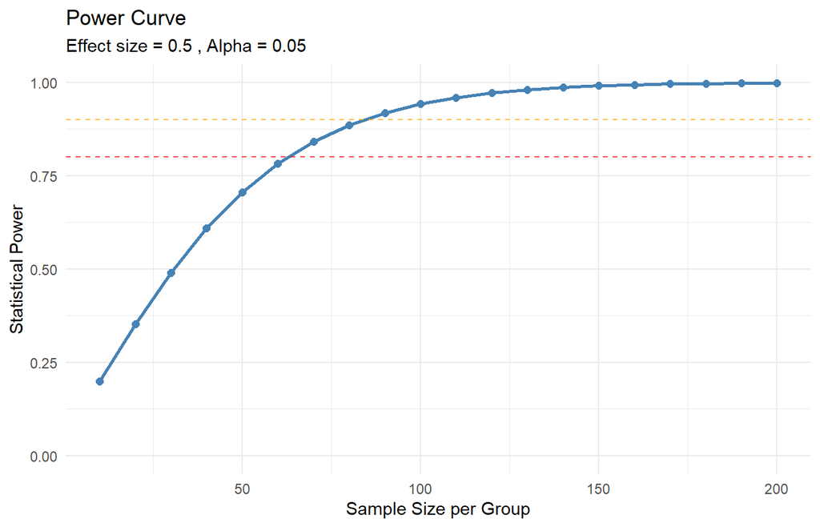

```r
plot_power_curve(n_range = seq(10, 200, by = 10), effect_size = 0.5)
```

## 2.3 效应量与功效曲线

**概念**：展示效应量大小对统计功效的影响，效应量越大所需样本越小。

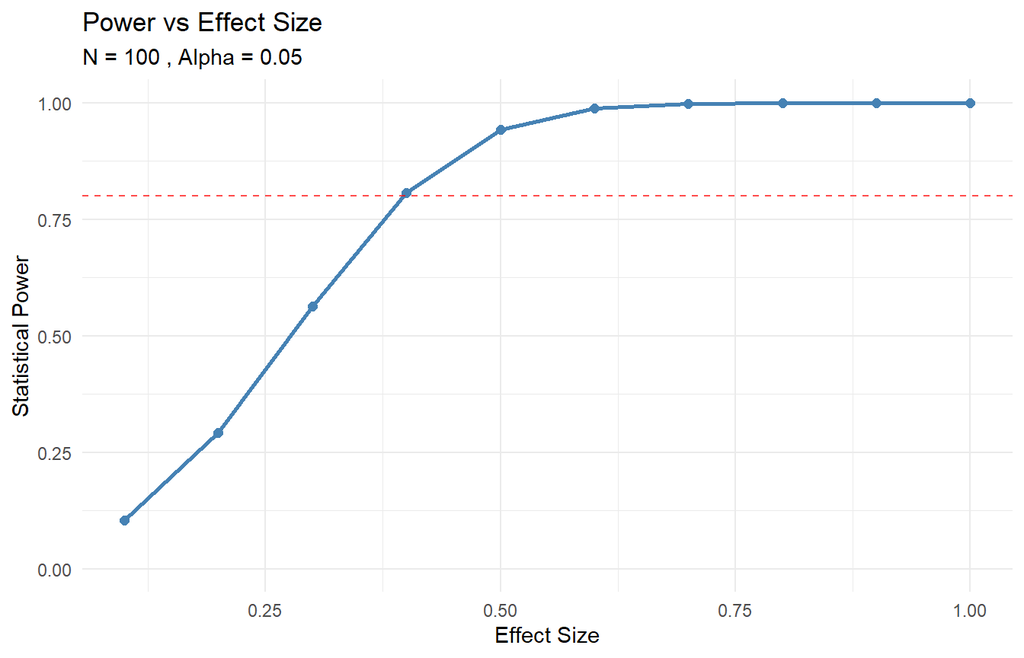

```r
plot_effect_size_curve(effect_range = seq(0.1, 1.0, by = 0.1), n = 100)
```

# 3. 统计分析

## 3.1 两样本t检验

**案例**：比较胰岛素与口服药治疗后的HbA1c水平。

```r
g_insulin <- omni_glucose$hba1c_3m[omni_glucose$treatment == "胰岛素"]
g_oral <- omni_glucose$hba1c_3m[omni_glucose$treatment == "口服药"]
stats_ttest(g_insulin, g_oral)
#
# === Statistical Test Results ===
# Method: Two-sample t-test
# Statistic: -2.8144
# P-value: 0.0052
# Estimate: 7.1011 7.6844 -0.5832
# 95% CI: -0.991 - -0.1755
```

## 3.2 Wilcoxon秩和检验

**概念**：非参数检验，适用于数据不满足正态分布的情况。

```r
stats_wilcoxon(g_insulin, g_oral)
#
# === Statistical Test Results ===
# Method: Wilcoxon rank-sum test
# Statistic: 11689
# P-value: 0.0072
```

## 3.3 单因素方差分析（ANOVA）

**案例**：比较三种治疗方式的HbA1c差异。

```r
stats_anova(omni_glucose$hba1c_3m, omni_glucose$treatment)
#
# === Statistical Test Results ===
# Method: One-way ANOVA
# Statistic: 4.8964
# P-value: 0.0078
# N: 500
# Groups: 3
```

## 3.4 相关分析

**案例**：年龄与BMI的Pearson相关性。

```r
stats_correlation(omni_glucose$age, omni_glucose$bmi)
#
# === Statistical Test Results ===
# Method: pearson correlation
# Statistic: 0.232
# P-value: 0.8166
# Estimate: 0.0104
# N: 500
# 95% CI: -0.0774 - 0.098
```

## 3.5 线性回归

**案例**：以HbA1c为因变量，探索年龄、BMI的影响。

```r
stats_regression(hba1c_3m ~ age + bmi, data = omni_glucose)
#
# === Statistical Test Results ===
# Method: Linear Regression
# R-squared: 0.0044
# Adjusted R-squared: 3e-04
# N: 500
#
# Coefficients:
#                Estimate  Std. Error   t value     Pr(>|t|)
# (Intercept) 6.294775280 0.764646506 8.2322684 1.630099e-15
# age         0.007882695 0.007143481 1.1034810 2.703523e-01
# bmi         0.025750083 0.026664657 0.9657009 3.346635e-01
#
# Formula: hba1c_3m ~ age + bmi
```

## 3.6 Logistic回归

**案例**：血糖控制不佳（HbA1c > 7）的危险因素分析。

```r
omni_glucose$poor_control <- ifelse(omni_glucose$hba1c_3m > 7, 1, 0)
stats_logistic_regression(poor_control ~ age + bmi, data = omni_glucose)
#
# === Statistical Test Results ===
# Method: Logistic Regression
# Converged: TRUE
# N: 500
#
# Odds Ratios:
#          OR   CI_lower CI_upper   p_value
# 1 0.4614374 0.09018526 2.360968 0.3531092
# 2 1.0083139 0.99304336 1.023819 0.2876029
# 3 1.0256902 0.96886892 1.085844 0.3830158
#
# Coefficients:
#                 Estimate Std. Error    z value  Pr(>|z|)
# (Intercept) -0.773408796 0.83289819 -0.9285754 0.3531092
# age          0.008279572 0.00778598  1.0633950 0.2876029
# bmi          0.025365762 0.02907741  0.8723530 0.3830158
```

## 3.7 卡方检验

**案例**：治疗组与并发症的相关性分析。

```r
stats_chisq(omni_glucose$treatment, omni_glucose$complications)
#
# === Statistical Test Results ===
# Method: Chi-square test
# Statistic: 12.1067
# P-value: 0.0596
# N: 500
```

## 3.8 Fisher精确检验

```r
stats_fisher_exact(omni_glucose$gender, omni_glucose$complications)
#
# === Statistical Test Results ===
# Method: Fisher's Exact Test
# P-value: 0.4038
```

## 3.9 正态性检验

```r
stats_normality(omni_glucose$hba1c_3m)
#
# === Statistical Test Results ===
# Method: Shapiro-Wilk normality test
# Statistic: 0.9971
# P-value: 0.5353
# N: 500
# Number of comparisons: -0.05784943
```

## 3.10 Kaplan-Meier生存分析

**案例**：癌症患者不同治疗的生存估计。

```r
stats_km_survival(omni_cancer$time_to_event, omni_cancer$status, omni_cancer$treatment)
#
# === Statistical Test Results ===
# Method: Kaplan-Meier (by group)
# N: 300
# Groups: 4
```

## 3.11 Log-rank检验

**案例**：比较不同治疗组的生存曲线差异。

```r
stats_logrank_test(omni_cancer$time_to_event, omni_cancer$status, omni_cancer$treatment)
#
# === Statistical Test Results ===
# Method: Log-rank test
# Statistic: 3.0983
# P-value: 0.3767
# N: 300
# Groups: 4
```

## 3.12 列联表分析

```r
crosstab(omni_glucose$gender, omni_glucose$complications)
#
# === Statistical Test Results ===
# P-value: 0.4062
#
#     y
# x    大血管 两者 微血管  无
#   男     83   25     65 120
#   女     46   20     55  86
```

# 4. 效应量

效应量衡量组间差异的大小，不受样本量影响，是P值的重要补充。

## 4.1 Cohen’s d

**概念**：标准化均数差，0.2=小，0.5=中，0.8=大效应。

```r
cohen_d(g_insulin, g_oral)
#
# === Effect Size ===
# Cohen's d: -0.309
# |d|: 0.309
# Interpretation: Small
```

## 4.2 Cohen’s f（ANOVA）

```r
cohen_f(ss_between = 100, ss_within = 400, k = 3)
#
# === Effect Size ===
# Cohen's f: 0.5
# Interpretation: Large
```

## 4.3 Cohen’s f²（回归）

```r
cohen_f2(r_squared = 0.25)
#
# === Effect Size ===
# Cohen's f: 0.3333
# Cohen's f-squared: 0.3333
# Interpretation: Large
```

## 4.4 比值比（OR）

**案例**：从2×2列联表计算OR及其95%置信区间。

```r
odds_ratio(a = 30, b = 20, c = 15, d = 35)
#
# === Statistical Test Results ===
# Method: Odds Ratio
# P-value: 0.0026
# 95% CI: 1.5288 - 8.0126
# Odds ratio: 3.5
#
#         Exposed Unexposed
# Case         30        15
# Control      20        35
```

## 4.5 相对危险度（RR）

```r
relative_risk(a = 30, b = 50, c = 15, d = 50)
#
# === Statistical Test Results ===
# Method: Relative Risk
# 95% CI: 1.2374 - 3.2325
# NNT: 4
```

## 4.6 风险比（HR）

**注意**：分组变量必须为二分类，如下将治疗组分为”手术” vs 其他：

```r
omni_cancer$surgery <- ifelse(omni_cancer$treatment == "手术", 1, 0)
hazard_ratio(omni_cancer$time_to_event, omni_cancer$status, omni_cancer$surgery)
#
# === Statistical Test Results ===
# Method: Hazard Ratio
# 95% CI: 0.8192 - 1.4499
# Groups: 2
```

## 4.7 需治疗人数（NNT）

**概念**：需要治疗多少患者才能避免1例不良结局。NNT=10表示每治疗10人可预防1例事件。

```r
nnt(p_treatment = 0.15, p_control = 0.25)
#
# === Statistical Test Results ===
# Method: Number Needed to Treat
# 95% CI: 4.7618 - Inf
# NNT: 10
```

# 5. 数据可视化

## 5.1 Kaplan-Meier生存曲线

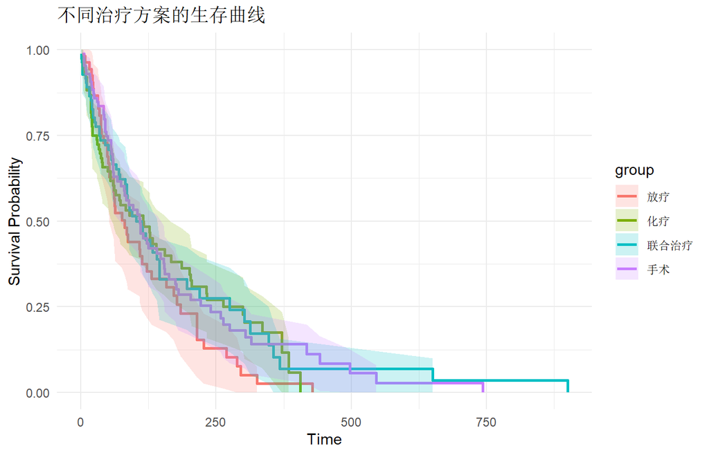

```r
plot_km_curve(omni_cancer$time_to_event, omni_cancer$status, omni_cancer$treatment,
              title = "不同治疗方案的生存曲线")
```

## 5.2 ROC曲线

**案例**：评估诊断试验的区分能力。AUC=0.9956提示极佳诊断价值。

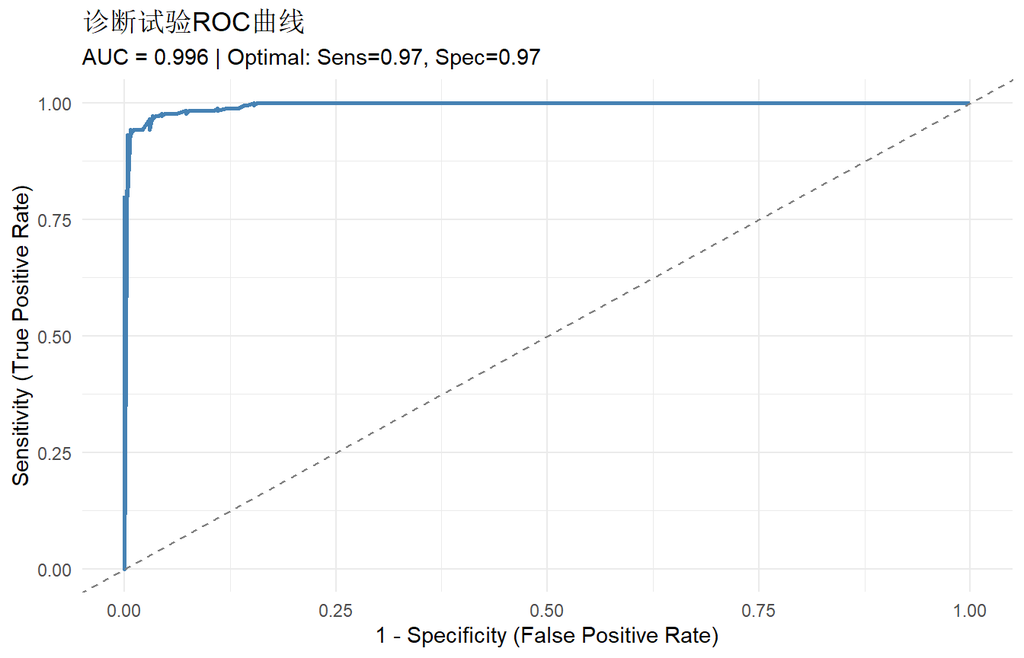

```r
disease_binary <- ifelse(omni_diagnostic$true_disease == "阳性", 1, 0)
plot_roc_enhanced(omni_diagnostic$test1_result, disease_binary,
                  title = "诊断试验ROC曲线")
#
# === ROC Analysis ===
# AUC: 0.9956
# Interpretation: Excellent
```

## 5.3 箱线图

**案例**：不同治疗组的HbA1c分布比较。

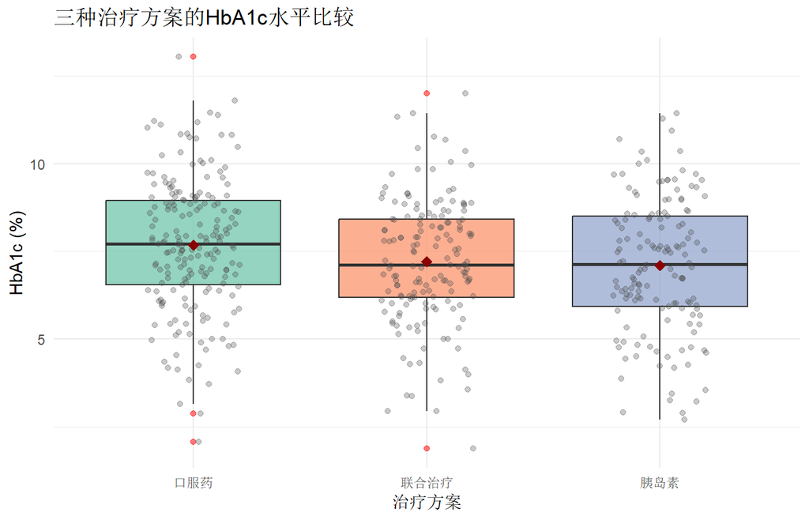

```r
plot_boxplot(omni_glucose$treatment, omni_glucose$hba1c_3m,
             title = "三种治疗方案的HbA1c水平比较",
             xlab = "治疗方案", ylab = "HbA1c (%)")
```

## 5.4 散点图

**案例**：年龄与HbA1c的相关关系。

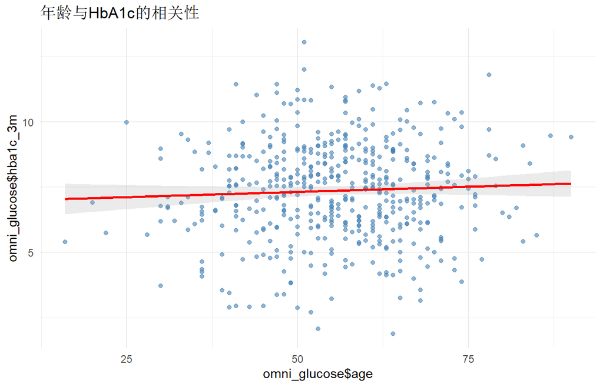

```r
plot_scatter(omni_glucose$age, omni_glucose$hba1c_3m,
             title = "年龄与HbA1c的相关性",
             reg_line = TRUE, conf_int = TRUE)
```

## 5.5 相关矩阵热图

**案例**：血糖相关指标的相关性矩阵。

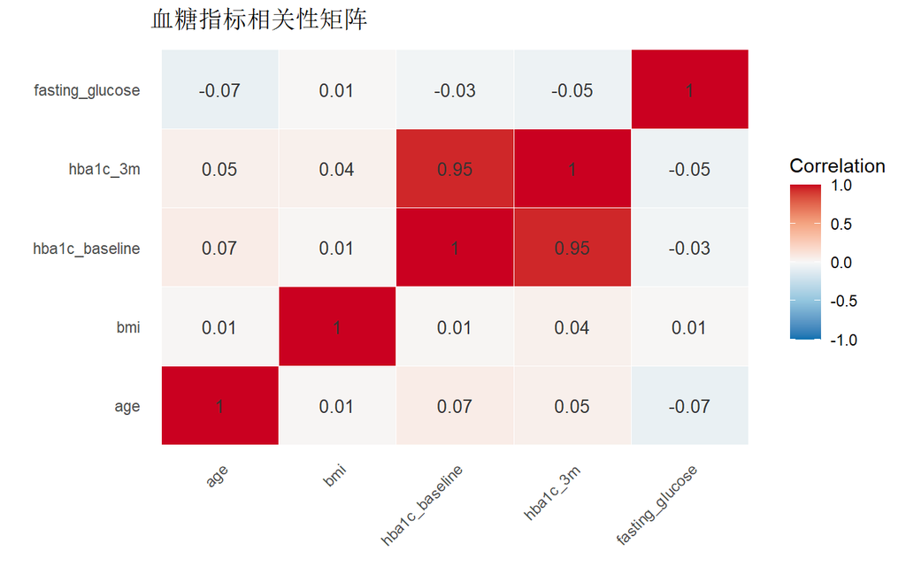

```r
plot_correlation_matrix(omni_glucose[, c("age", "bmi", "hba1c_baseline",
                                          "hba1c_3m", "fasting_glucose")],
                        title = "血糖指标相关性矩阵")
```

## 5.6 火山图

**案例**：差异分析中标记显著变化的变量。

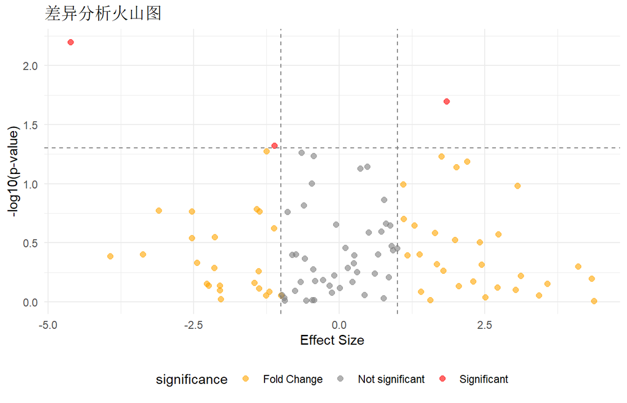

```r
set.seed(123)
fc <- rnorm(100, 0, 2)
pval <- runif(100, 0, 1)
plot_volcano(fc, pval, fc_threshold = 1, p_threshold = 0.05,
             title = "差异分析火山图")
```

## 5.7 森林图（Meta分析）

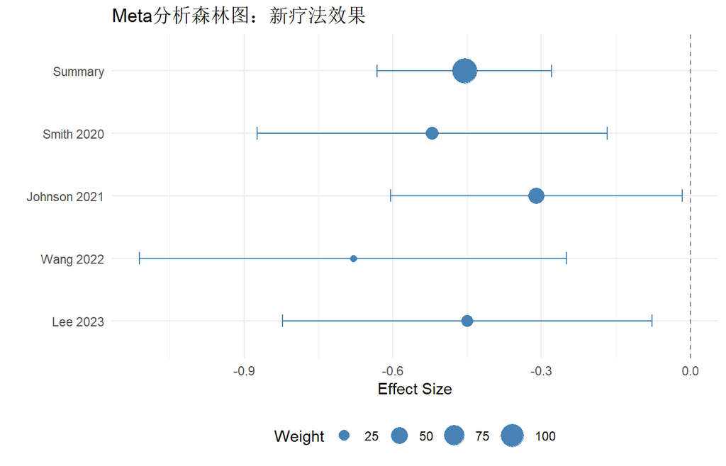

```r
plot_forest_meta(
  studies = c("Smith 2020", "Johnson 2021", "Wang 2022", "Lee 2023"),
  effects = c(-0.52, -0.31, -0.68, -0.45),
  se = c(0.18, 0.15, 0.22, 0.19),
  title = "Meta分析森林图：新疗法效果"
)
```

## 5.8 Bland-Altman图

**案例**：比较两种测量方法的一致性。

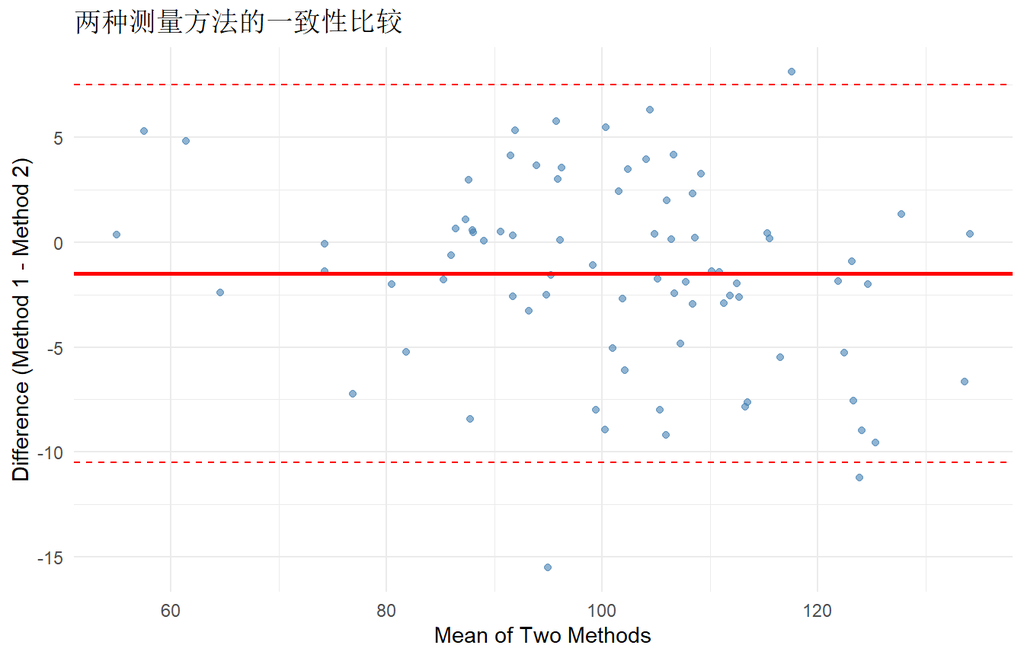

```r
set.seed(42)
method1 <- rnorm(80, 100, 15)
method2 <- method1 + rnorm(80, 2, 5)
plot_bland_altman(method1, method2, title = "两种测量方法的一致性比较")
```

# 6. 诊断试验评价

**概念**：评估诊断试验的灵敏度、特异度、预测值和似然比。

```r
diag_test_performance(omni_diagnostic$test1_positive, omni_diagnostic$true_disease)
#
# === Statistical Test Results ===
# Method: Diagnostic Test Performance
# Sensitivity: 0.9708
# Specificity: 0.9432
# PPV: 0.9638
# NPV: 0.954
# Prevalence: 0.6089
# Accuracy: 0.96
# LR+: 17.0861
# LR-: 0.031
#
#       Disease+ Disease-
# Test+      266        8
# Test-       10      166
```

# 7. Table One 基线特征表

**概念**：临床试验论文中标准的基线特征描述，按分组展示变量的分布。

```r
table_one(omni_glucose,
          vars = c("age", "bmi", "hba1c_baseline", "hba1c_3m",
                   "gender", "complications", "diabetes_type"),
          group = "treatment")
#
# === Table 1: Baseline Characteristics ===
#
#        Variable
#             age
#             bmi
#  hba1c_baseline
#        hba1c_3m
#          gender
#   complications
#   diabetes_type
#                                                                   口服药
#                                                            54.39 (12.14)
#                                                             24.55 (3.22)
#                                                              8.48 (1.82)
#                                                              7.68 (1.88)
#                                          男: 117 (60.6%); 女: 76 (39.4%)
#  大血管: 60 (31.1%); 两者: 17 (8.8%); 微血管: 44 (22.8%); 无: 72 (37.3%)
#                   1型: 25 (13%); 2型: 151 (78.2%); 妊娠糖尿病: 17 (8.8%)
#                                                                联合治疗
#                                                           56.42 (11.61)
#                                                            24.65 (3.09)
#                                                             8.45 (1.75)
#                                                             7.22 (1.76)
#                                          男: 97 (60.2%); 女: 64 (39.8%)
#  大血管: 29 (18%); 两者: 17 (10.6%); 微血管: 48 (29.8%); 无: 67 (41.6%)
#                1型: 14 (8.7%); 2型: 127 (78.9%); 妊娠糖尿病: 20 (12.4%)
#                                                                   胰岛素
#                                                            56.41 (11.03)
#                                                             24.11 (3.03)
#                                                               8.6 (1.87)
#                                                                7.1 (1.9)
#                                           男: 79 (54.1%); 女: 67 (45.9%)
#  大血管: 40 (27.4%); 两者: 11 (7.5%); 微血管: 28 (19.2%); 无: 67 (45.9%)
#                1型: 18 (12.3%); 2型: 110 (75.3%); 妊娠糖尿病: 18 (12.3%)
#  P-value
#
#
#
#
#   0.4234
#   0.0596
#    0.547
```

# 8. 临床工具

## 8.1 BMI计算与分类

```r
calculate_bmi(weight = 70, height = 1.75)
#
# === Clinical Calculation ===
# BMI: 22.86 kg/m²
# Category: Normal
```

## 8.2 eGFR估算（CKD-EPI 2021）

```r
calculate_egfr(creatinine = 1.2, age = 50, sex = "male")
#
# === Clinical Calculation ===
# eGFR: 73.67 mL/min/1.73m²
# CKD Stage: G2
```

# 9. 实用工具函数

## 9.1 描述统计

```r
summary_stats(omni_glucose$hba1c_3m)
#
# === Statistical Test Results ===
# N: 500
# Number of comparisons: -0.05784943
```

## 9.2 缺失值填补

```r
test_data <- omni_glucose
test_data$age[1:5] <- NA
imputed <- impute_missing(test_data, method = "median")
cat("填补后缺失数:", sum(is.na(imputed$age)), "\n")
# 填补后缺失数: 0
```

## 9.3 多重比较校正

```r
p_vals <- c(0.01, 0.03, 0.05, 0.1, 0.2)
multiple_testing_correction(p_vals, method = "fdr")
#   original   adjusted significant
# 1     0.01 0.05000000       FALSE
# 2     0.03 0.07500000       FALSE
# 3     0.05 0.08333333       FALSE
# 4     0.10 0.12500000       FALSE
# 5     0.20 0.20000000       FALSE
```

## 9.4 FWER控制（Holm-Bonferroni）

```r
fwer_control(p_vals)
#
# === Statistical Test Results ===
# Method: Holm-Bonferroni
#
# Formula: Holm-Bonferroni: α_adj(k) = α / (n - k + 1)
# Reference: Holm (1979) Scandinavian Journal of Statistics, 6(2), 65-70
```

## 9.5 Alpha水平校正

```r
adjust_alpha(alpha = 0.05, k = 5)
#
# === Statistical Test Results ===
# Method: bonferroni
# Original alpha: 0.05
# Adjusted alpha: 0.01
# Number of comparisons: 5
#
# Formula: α_adj = α / k
# Reference: Bonferroni (1936) or Šidák (1967) multiple comparison correction
```

## 9.6 Bootstrap置信区间

```r
bootstrap_ci(omni_glucose$hba1c_3m, statistic = mean, n_bootstrap = 500)
#
# === Statistical Test Results ===
# Statistic: 7.363
# 95% CI: 7.2048 - 7.5217
# Bootstrap mean: 7.3596
# Bootstrap SE: 0.0839
# Bootstrap replicates: 500
```

## 9.7 统计假设检验

```r
check_assumptions(omni_glucose$hba1c_3m, "ttest",
                  group = omni_glucose$treatment)
#
# === Statistical Test Results ===
# Method: Assumption Check (t-test)
```

## 9.8 哑变量创建

```r
dummy <- create_dummy_vars(omni_glucose, vars = "treatment")
names(dummy)[(ncol(dummy)-2):ncol(dummy)]
# [1] "poor_control"        "treatment_x联合治疗" "treatment_x胰岛素"
```

# 参考文献

- Chow, S.C., Shao, J., Wang, H., & Lokhnygina, Y. (2017). *Sample Size Calculations in Clinical Research* (3rd ed.). Chapman and Hall/CRC.
- Cohen, J. (1988). *Statistical Power Analysis for the Behavioral Sciences* (2nd ed.). Lawrence Erlbaum Associates.
- Riley, R.D., et al. (2020). Calculating the sample size required for developing a clinical prediction model. *BMJ*, 368, m441.
- Hsieh, F.Y., Bloch, D.A., & Larsen, M.D. (1998). A simple method of sample size calculation for linear and logistic regression. *Statistics in Medicine*, 17(14), 1623-1634.
- Schoenfeld, D.A. (1983). Sample-size formula for the proportional-hazards regression model. *Biometrics*, 39(2), 499-503.
- Freedman, L.S. (1982). Tables of the number of patients required in clinical trials using the logrank test. *Statistics in Medicine*, 1(2), 121-129.
- Hanley, J.A. & McNeil, B.J. (1982). The meaning and use of the area under a ROC curve. *Radiology*, 143(1), 29-36.
- Buderer, N.M.F. (1996). Incorporating the prevalence of disease into the sample size calculation for sensitivity and specificity. *Academic Emergency Medicine*, 3(9), 895-900.